# Compensating Wage Differentials

Labour Economics, ECON207 — UG-II, 2026: Semester IV

Ravikiran Naik

Department of Economics, FLAME University

March 2026

## Sections Covered

| § | Topic |
| --- | --- |
| 5-1 | The Market for Risky Jobs |
| 5-2 | The Hedonic Wage Function |
| 5-3 | Policy: How Much Is a Life Worth? |
| 5-4 | Policy: Safety and Health Regulations |
| 5-5 | Compensating Differentials and Job Amenities |
| 5-6 | Policy: Health Insurance and the Labor Market |

## What Are Compensating Wage Differentials?

- The labour market is not characterised by a single wage: **workers differ** and **jobs differ**.
- Adam Smith (1776) first proposed that **job characteristics** influence labour market equilibrium.
- **Compensating wage differentials** arise to compensate workers for nonwage characteristics of the job.
- Workers have different **preferences**, and firms offer different **working conditions** — the market matches them.

## Why Do Workers Care About Job Risk?

- Workers care about whether their job is **safe** or **risky**.
- **Indifference curves** in wage–risk space slope **upward** because risk is a “bad.”
- A worker requires a higher wage to accept more risk — the steeper the IC, the more **risk-averse** the worker.
- Firms may prefer a risky work environment because it is **less expensive** to pay higher wages than to make the workplace safe.

## How Do Workers Choose Between Safe and Risky Jobs?

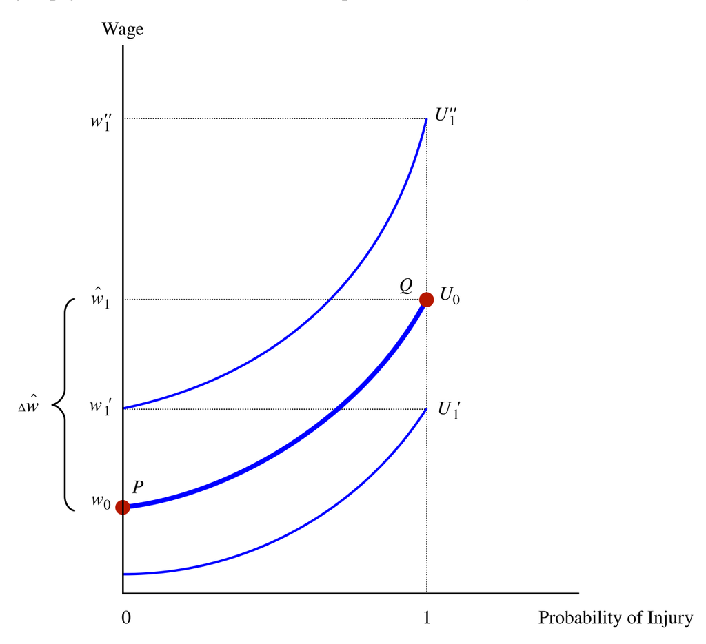

*Figure 5-1: Indifference Curves between the Wage and the Probability of Injury*

## How Does the Market Determine the Compensating Differential?

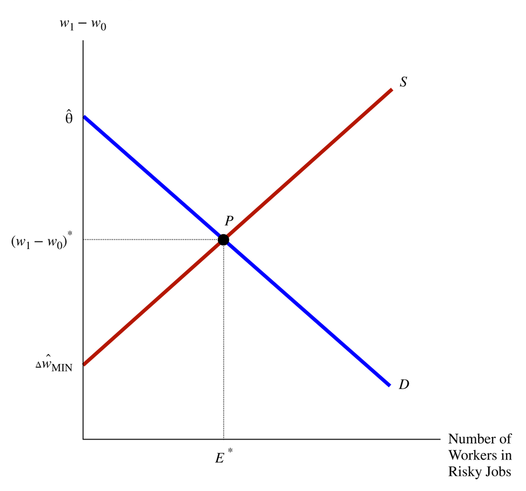

*Figure 5-2: The Market Compensating Differential*

## What If Some Workers Prefer Risky Jobs?

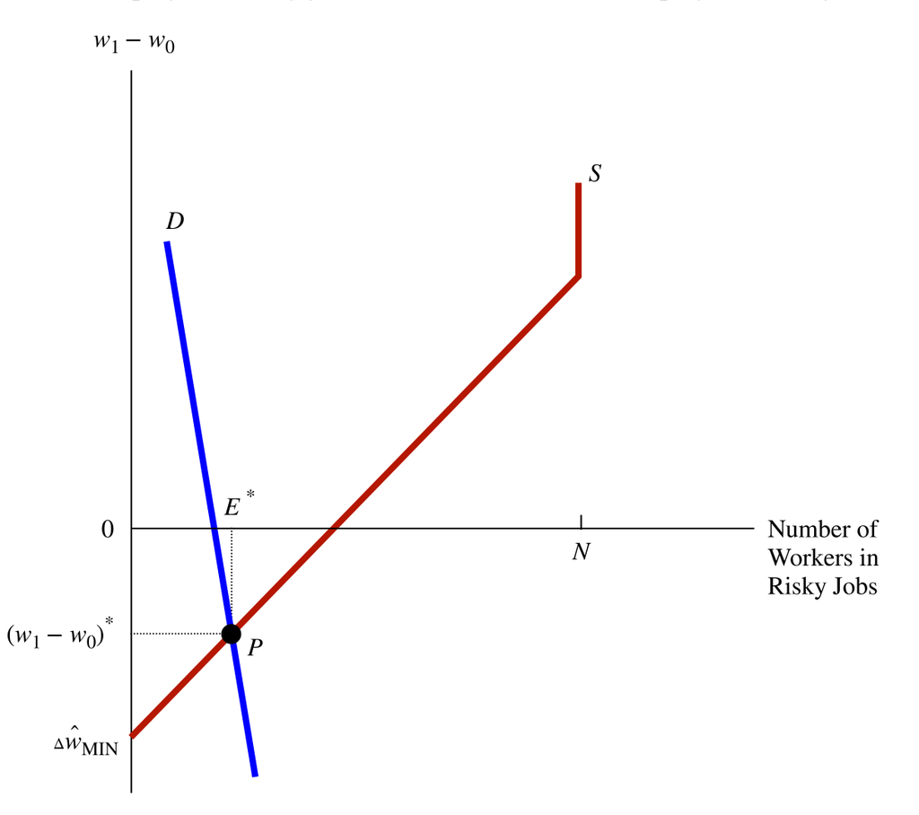

*Figure 5-3: Market Equilibrium When Some Workers Prefer Risky Jobs*

## What Is Hedonic Wage Theory?

- Workers maximise utility by choosing **wage–risk combinations**; firms maximise profits subject to technology.
- **Isoprofit curves** are **upward-sloping** (risk requires higher wages) and **concave** (diminishing returns to safety).
- The **hedonic wage function** (Rosen 1974) traces the equilibrium relationship between wages and job characteristics.
- It is a **market outcome** — the envelope of tangency points, not any single agent’s curve.

## How Do Different Workers Value Risk?

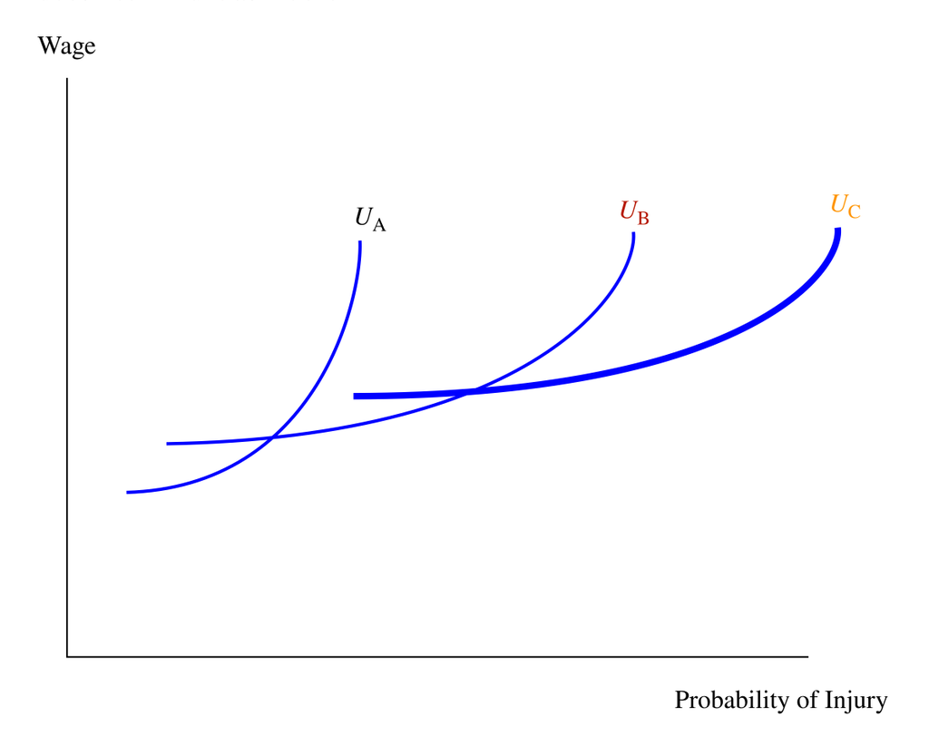

*Figure 5-4: Indifference Curves for Different Types of Workers*

## What Are Isoprofit Curves?

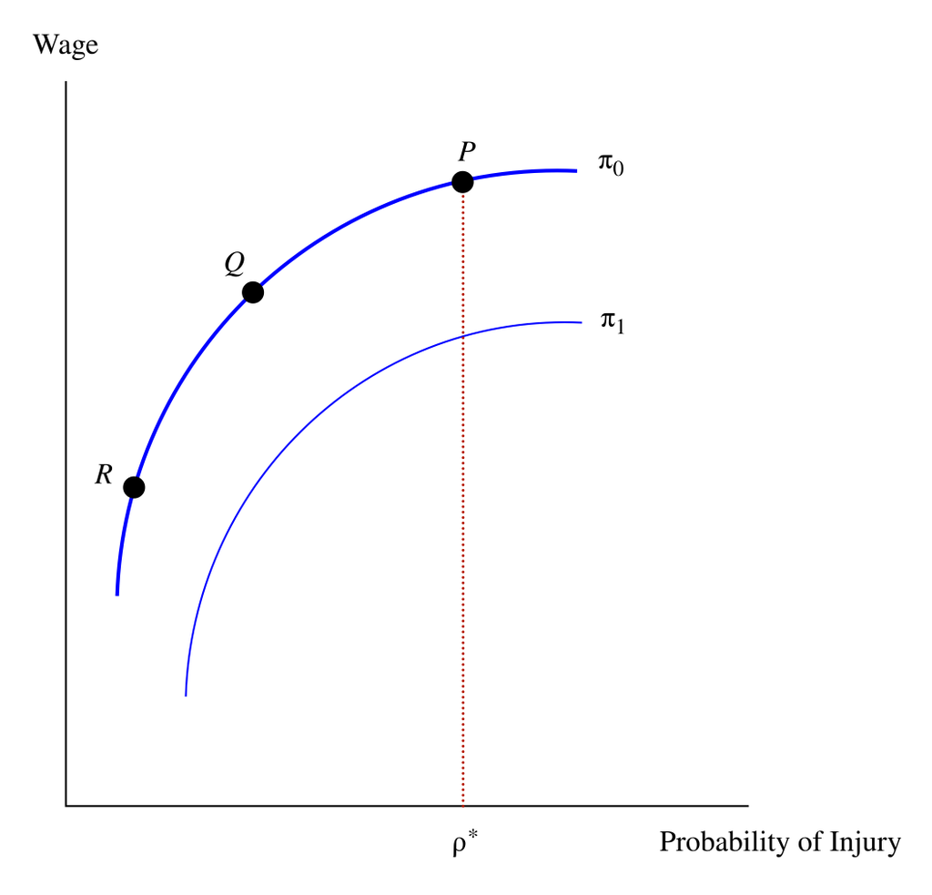

*Figure 5-5: The Isoprofit Curve*

## How Does the Hedonic Wage Function Emerge?

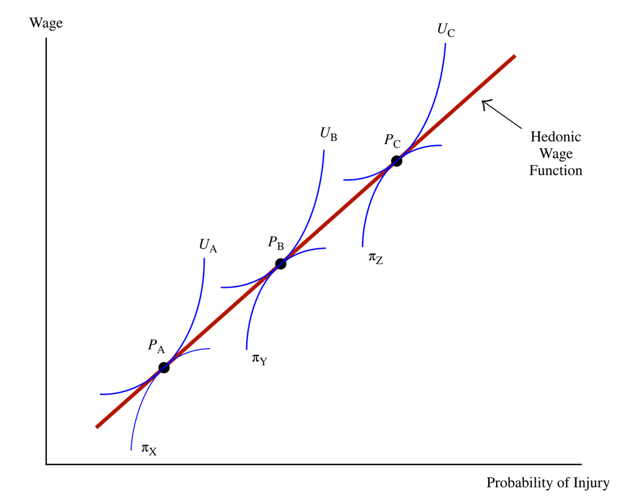

*Figure 5-6: The Hedonic Wage Function*

## How Does Safety Regulation Affect the Labour Market?

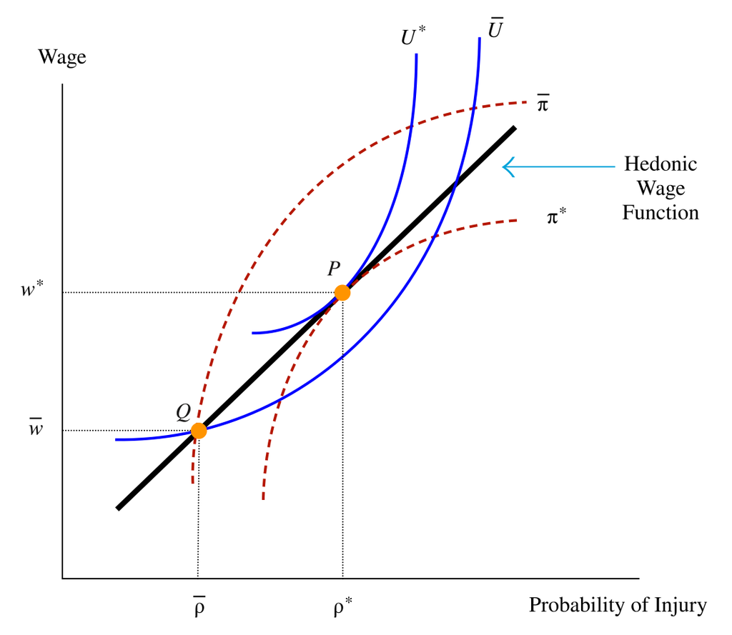

*Figure 5-7: Impact of OSHA Regulation on Wages, Utility, and Profits*

## What If Workers Misperceive Risks?

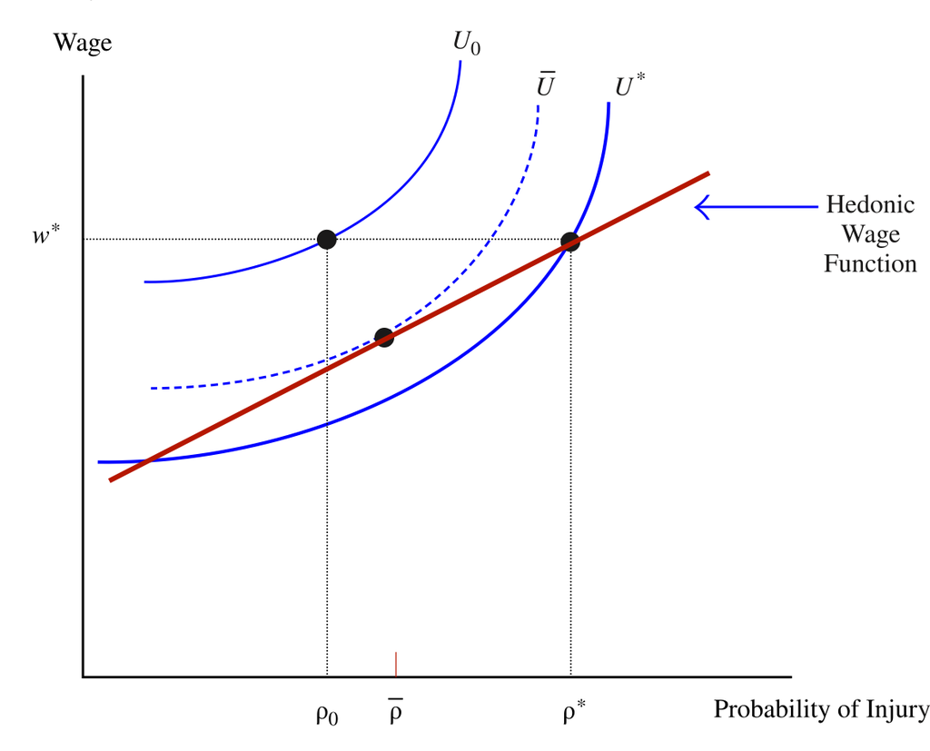

*Figure 5-8: Workers Misperceive Risks on the Job*

## How Do Job Amenities Affect Wages?

- **Good** characteristics (flexibility, security) → lower wages; **bad** characteristics (danger, instability) → higher wages.
- Strongest evidence: **risk of death** — robust positive wage–fatality relationship (Viscusi & Aldy 2003).
- Clean examples: **night-shift nurses** earn ~12% more; **German smoking ban** (2007–08) made waiter jobs pleasant → wages fell 1–2%.
- The identification challenge: observed gaps may reflect **who selects into those jobs**, not the amenity’s true price.

## How Do Layoffs Create Compensating Differentials?

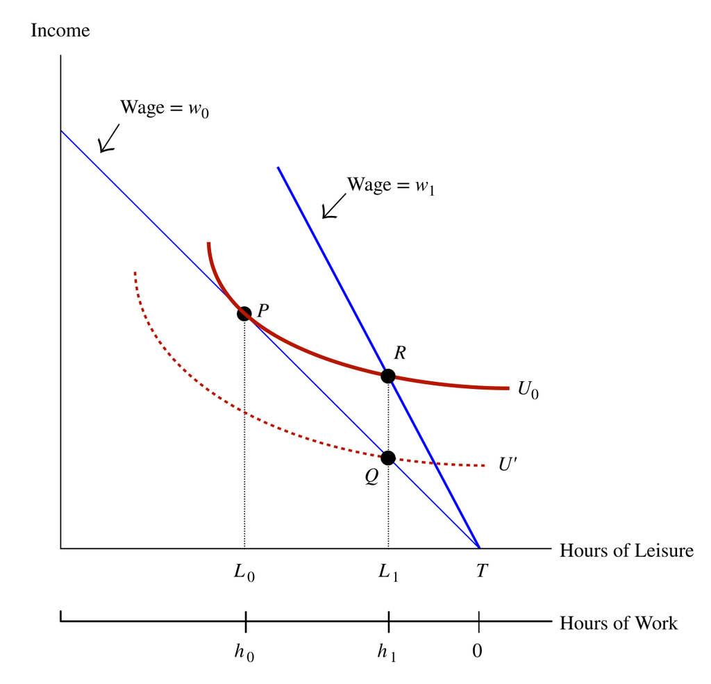

*Figure 5-9: Layoffs and Compensating Differentials*

## How Do Health Benefits Trade Off Against Wages?

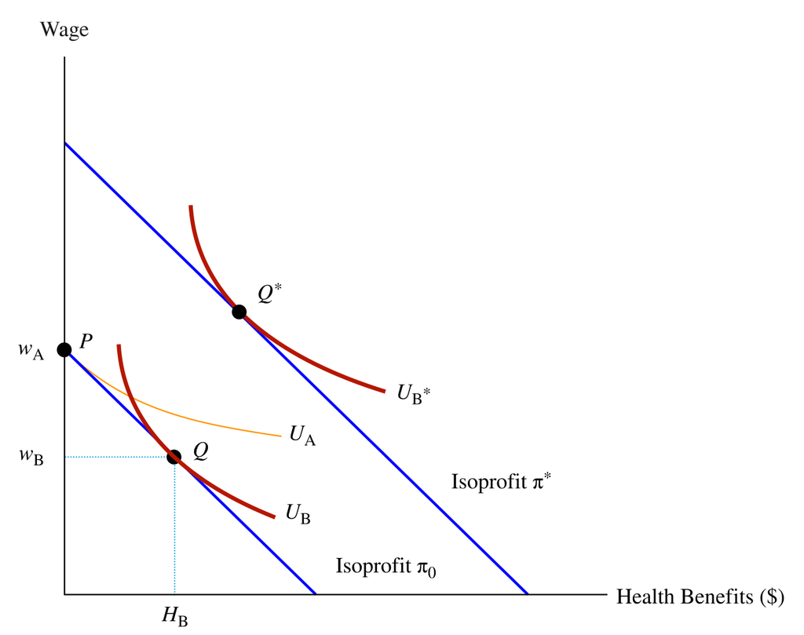

*Figure 5-10: Health Benefits and Compensating Differentials*

## Review — Compensating Differentials

- **CWDs** arise because jobs differ in nonwage characteristics; the market differential can be positive, zero, or negative.
- The equilibrium differential is set by the **marginal worker** — inframarginal workers earn rents.
- **Hedonic wage theory** matches risk-averse workers with safe firms — the hedonic function’s slope measures the market price of risk.

## Review — Regulation & Amenities

- Safety regulation **reduces** welfare when workers are informed; **improves** it when they misperceive risks. VSL quantifies the trade-off.
- Good amenities lower wages, bad ones raise them — but observed gaps may reflect **selection**, not the amenity’s true price.
- Health benefits trade off against wages at a slope of approximately −1; high-ability workers receive both, creating a data trap.

*“You become what you give your attention to.”*

**— Epictetus**